# Practical Machine Learning Course Project

D. McNelly

June 10, 2018

## Executive Summary

The goal of this analysis is to predict a weight lifting activity based on instrument data. Predictive models are built using the Random Forest, Gradiant Boosting, and Linear Discriminant Analysis methods. The Random Forest model is found to be the most accurate method for predicting the activity in the validation data set, with an accuracy of 99%. The R programming language, version 3.4.3, was used for performing all analyses.

## Dataset Source and Description

The data comes from: http://groupware.les.inf.puc-rio.br/har. The below two paragraphs are paraphrased from this website.

Six young health participants were asked to perform one set of 10 repetitions of the Unilateral Dumbbell Biceps Curl in five different fashions: exactly according to the specification (Class A), throwing the elbows to the front (Class B), lifting the dumbbell only halfway (Class C), lowering the dumbbell only halfway (Class D) and throwing the hips to the front (Class E).

Class A corresponds to the specified (correct) execution of the exercise, while the other 4 classes correspond to common mistakes. Participants were supervised by an experienced weight lifter to make sure the execution complied to the manner they were supposed to simulate. The exercises were performed by six male participants aged between 20-28 years, with little weight lifting experience. It was ensured that all participants could easily simulate the mistakes in a safe and controlled manner by using a relatively light dumbbell (1.25kg).

## Data Format

The training data is available at https://d396qusza40orc.cloudfront.net/predmachlearn/pml-training.csv

The training dataset include 160 variables and 19622 observations. During the analysis, this training set is randomly split into two datasets: a dataset used to create the models, and a dataset used to validate the models

The test data is available at https://d396qusza40orc.cloudfront.net/predmachlearn/pml-testing.csv

The testing dataset include 160 variables and 20 observations.The goal of this analysis is to correctly predict the class for each observation in the testing data.

## Variable Selection

Some variables in the datasets were not used in the analysis. The variable type and usage in the model is summarized below:

| Variable Type | Used in analysis | Reason |
| --- | --- | --- |
| Class | Yes | The variable that the model attempts to predict |
| Roll, pitch, and yaw of each of the 4 sensors | Yes | Assumed to be important variables |
| Acceleration in X, Y, and Z of each of the 4 sensors | Yes | Assumed to be important variables |
| Participant Name | No | Not relevent to the analysis |
| Time of observation | No | Not relevent to the analysis |
| Total acceleration (RMS of X,Y, and Z) | No | Redundant data of acceleration X, Y, Z |
| Raw magnetic compass data | No | Redundant data of roll, pitch and yaw in X, Y, Z |
| Raw gyro data | No | Redundant data of roll, pitch, yaw, and acceleration in X, Y, Z |
| Standard Deviation of measurement data per activity | No | NA or missing for most observations |
| Mean of measurement data per activity | No | NA or missing for most observations |
| Variances of measurement data per activity | No |  |
| Maximums of measurement data per activity | No | NA or missing for most observations |
| Kurtosis of measurement data per activity | No | NA or missing for most observations |
| Skewness of measurement data per activity | No | NA or missing for most observations |

## Setup for analysis

This code loads R libraries that are used in the analysis.

```r
library(caret)
library(tictoc)
library(parallel)
library(doParallel)
library(ggplot2)

#set up parallel processing
cluster <- makeCluster(detectCores() - 1)
registerDoParallel(cluster)
```

## Loading and Cleaning the Data

The below code reads the data from the dataset files and selects the variables used for the model mentioned above.

In addition, the training set is randomly split into two datasets: a dataset used to create the models, and a dataset used to validate the models. The training dataset is set to be 75% of the original dataset, and the validation dataset consists of the remaining 25%. Due to the use of random numbers in some of the operations, a random seed is set before each such operation.

```r
training_raw <- read.csv("pml-training.csv")
testing <- read.csv("pml-testing.csv")

# make dataframe of training variables to be analyzed
training_full <- subset(training_raw, select = c(
      classe,
      roll_belt,
      pitch_belt,
      yaw_belt,
      accel_belt_x,
      accel_belt_y,
      accel_belt_z,
      roll_arm,
      pitch_arm,
      yaw_arm,
      accel_arm_x,
      accel_arm_y,
      accel_arm_z,
      roll_dumbbell,
      pitch_dumbbell,
      yaw_dumbbell,
      accel_dumbbell_x,
      accel_dumbbell_y,
      accel_dumbbell_z,
      roll_forearm,
      pitch_forearm,
      yaw_forearm,
      accel_forearm_x,
      accel_forearm_y,
      accel_forearm_z
))

#remove incomplete cases (NAs) from training set
training_full <- training_full[complete.cases(training_full),]

# make dataframe of training variables to be analyzed
testing <- subset(testing, select = c(
      roll_belt,
      pitch_belt,
      yaw_belt,
      accel_belt_x,
      accel_belt_y,
      accel_belt_z,
      roll_arm,
      pitch_arm,
      yaw_arm,
      accel_arm_x,
      accel_arm_y,
      accel_arm_z,
      roll_dumbbell,
      pitch_dumbbell,
      yaw_dumbbell,
      accel_dumbbell_x,
      accel_dumbbell_y,
      accel_dumbbell_z,
      roll_forearm,
      pitch_forearm,
      yaw_forearm,
      accel_forearm_x,
      accel_forearm_y,
      accel_forearm_z
))

#partition the data into training and validation datasets
set.seed(12345)
inTrain <- createDataPartition(training_full$classe, p = 3/4)[[1]]
training <- training_full[inTrain,]
validation <- training_full[-inTrain,]
```

## Modeling

The following code generates models using the Random Forest, Gradiant Boosting, and Linear Discriminant Analysis methods. A combined model is generated using these three methods using the Random Forest method.

```r
#Create the models
fitControl <- trainControl(method = "repeatedcv",
                           number = 5,
                           allowParallel = TRUE)
set.seed(12345)
forestmodel <- train(classe ~ ., method = "rf", data = training,  trControl = fitControl, verbose = FALSE, importance = TRUE)

set.seed(12345)
boostmodel <- train(classe ~ ., method = "gbm", data = training, trControl = fitControl, verbose = FALSE)

set.seed(12345)
ldamodel <- train(classe ~ ., method = "lda", data = training,  trControl = fitControl)

#use the models to make predictions on validation data
forestpredict <- predict(forestmodel, newdata = validation)
boostpredict <- predict(boostmodel, newdata = validation)
ldapredict <- predict(ldamodel, newdata = validation)

#make a combined model based on above 3 prediction methods
predDF <- data.frame(forestpredict,
                     boostpredict,
                     ldapredict,
                     classe = validation$classe)
set.seed(12345)
combinedmodel <- train(classe ~., method = "rf", data = predDF, verbose = FALSE,  trControl = fitControl)
combinedpredict <- predict(combinedmodel, predDF)
```

## Prediction Accuracy

Confusion matrices are generated in order to evaluate the accuracy of each model compared to the validation dataset.

```r
#Create confusion matrices
cm_forest <- confusionMatrix(forestpredict, reference = validation$classe)
cm_boost <- confusionMatrix(boostpredict, reference = validation$classe)
cm_lda <- confusionMatrix(ldapredict, reference = validation$classe)
cm_combined <- confusionMatrix(combinedpredict, reference = validation$classe)

accuracy <- as.data.frame(as.list(c(
      as.numeric(cm_forest$overall[1]),
      as.numeric(cm_boost$overall[1]),
      as.numeric(cm_lda $overall[1]),
      as.numeric(cm_combined$overall[1]))))
colnames(accuracy) <- c("Random Forest", "Gradient Boosting", "LDA", "Combined Model")
accuracy
```

```
##   Random Forest Gradient Boosting       LDA Combined Model
## 1     0.9902121         0.9463703 0.5662724      0.9902121
```

As can be seen above, the Random Forest and Gradient Boosting models have high prediction accuracy on the validation data set. The Linear Discriminant Analysis (LDA) model is significantly less accurate.

Since the combined model is not more accurate than the Random Forest model, the Random Forest model is used for subsequent investigation. The confusion matrix of the Random Forest model is shown below.

```r
cm_forest
```

```
## Confusion Matrix and Statistics
##
##           Reference
## Prediction    A    B    C    D    E
##          A 1391   10    0    1    0
##          B    2  933    4    1    0
##          C    0    5  846    8    2
##          D    2    0    5  794    7
##          E    0    1    0    0  892
##
## Overall Statistics
##
##                Accuracy : 0.9902
##                  95% CI : (0.987, 0.9928)
##     No Information Rate : 0.2845
##     P-Value [Acc > NIR] : < 2.2e-16
##
##                   Kappa : 0.9876
##  Mcnemar's Test P-Value : NA
##
## Statistics by Class:
##
##                      Class: A Class: B Class: C Class: D Class: E
## Sensitivity            0.9971   0.9831   0.9895   0.9876   0.9900
## Specificity            0.9969   0.9982   0.9963   0.9966   0.9998
## Pos Pred Value         0.9922   0.9926   0.9826   0.9827   0.9989
## Neg Pred Value         0.9989   0.9960   0.9978   0.9976   0.9978
## Prevalence             0.2845   0.1935   0.1743   0.1639   0.1837
## Detection Rate         0.2836   0.1903   0.1725   0.1619   0.1819
## Detection Prevalence   0.2859   0.1917   0.1756   0.1648   0.1821
## Balanced Accuracy      0.9970   0.9907   0.9929   0.9921   0.9949
```

## Variable Importance

```r
head(varImp(forestmodel)$importance)
```

```
##                      A         B          C         D         E
## roll_belt    76.391454 87.065834 81.0771242 82.385314 100.00000
## pitch_belt   33.056174 89.384140 77.6471660 57.152337  44.17689
## yaw_belt     61.132033 65.416866 69.7344861 77.985444  38.18071
## accel_belt_x  2.081307 14.446808 20.6459716  5.847171  10.56929
## accel_belt_y  0.190132  9.625818  0.4141373  3.326123   0.00000
## accel_belt_z 16.285065 31.630372 28.7485585 20.574824  15.97804
```

The plot below shows the activity predicted by the Random Forest model vs the observed activity in the validation dataset.

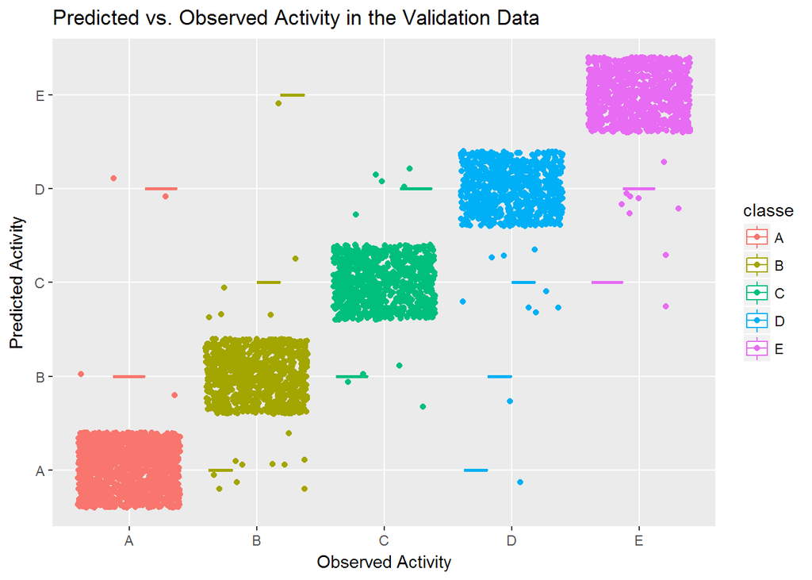

## Prediction of the Class Variable in the Test Dataset

The goal of this model, to predict the “class” variable in the test dataset, is performed below.

```r
predict(forestmodel, newdata = testing)
```

```
##  [1] B A B A A E D B A A B C B A E E A B B B
## Levels: A B C D E
```